# AnaliseBackHomeBrazilSerieA

## Análise Back Home - Brasileirão Série A

Neste Artigo vamos analisar o percentual de vitórias do time mandante em relação às derrotas e empates do campeonato brasileiro Séria A na temporada 2023.

Vamos utizar *Python* como liguagem de programação e a biblioteca *Pandas* para manipular os dados. Utilizaremos também os dados do site www.football-data.co.uk.

- Vamos iniciar importando as bibliotecas

```python
import pandas as pd
import matplotlib.pyplot as plt
```

- Vamos importar nossa base de dados usando o link: 'https://www.football-data.co.uk/new/BRA.csv', a partir desse momento nossa base será um *DataFrame Pandas*

```python
base = pd.read_csv("https://www.football-data.co.uk/new/BRA.csv")
base
```

|  | Country | League | Season | Date | Time | Home | Away | HG | AG | Res | PH | PD | PA | MaxH | MaxD | MaxA | AvgH | AvgD | AvgA |
| --- | --- | --- | --- | --- | --- | --- | --- | --- | --- | --- | --- | --- | --- | --- | --- | --- | --- | --- | --- |
| 0 | Brazil | Serie A | 2012 | 19/05/2012 | 22:30 | Palmeiras | Portuguesa | 1.0 | 1.0 | D | 1.75 | 3.86 | 5.25 | 1.76 | 3.87 | 5.31 | 1.69 | 3.50 | 4.90 |
| 1 | Brazil | Serie A | 2012 | 19/05/2012 | 22:30 | Sport Recife | Flamengo RJ | 1.0 | 1.0 | D | 2.83 | 3.39 | 2.68 | 2.83 | 3.42 | 2.70 | 2.59 | 3.23 | 2.58 |
| 2 | Brazil | Serie A | 2012 | 20/05/2012 | 01:00 | Figueirense | Nautico | 2.0 | 1.0 | H | 1.60 | 4.04 | 6.72 | 1.67 | 4.05 | 7.22 | 1.59 | 3.67 | 5.64 |
| 3 | Brazil | Serie A | 2012 | 20/05/2012 | 20:00 | Botafogo RJ | Sao Paulo | 4.0 | 2.0 | H | 2.49 | 3.35 | 3.15 | 2.49 | 3.39 | 3.15 | 2.35 | 3.26 | 2.84 |
| 4 | Brazil | Serie A | 2012 | 20/05/2012 | 20:00 | Corinthians | Fluminense | 0.0 | 1.0 | A | 1.96 | 3.53 | 4.41 | 1.96 | 3.53 | 4.41 | 1.89 | 3.33 | 3.89 |
| ... | ... | ... | ... | ... | ... | ... | ... | ... | ... | ... | ... | ... | ... | ... | ... | ... | ... | ... | ... |
| 4555 | Brazil | Serie A | 2023 | 07/12/2023 | 00:30 | Fluminense | Gremio | 2.0 | 3.0 | A | 2.08 | 3.92 | 3.35 | 2.16 | 3.96 | 3.45 | 2.08 | 3.75 | 3.23 |
| 4556 | Brazil | Serie A | 2023 | 07/12/2023 | 00:30 | Internacional | Botafogo RJ | 3.0 | 1.0 | H | 2.10 | 3.38 | 3.71 | 2.18 | 3.51 | 3.86 | 2.09 | 3.36 | 3.56 |
| 4557 | Brazil | Serie A | 2023 | 07/12/2023 | 00:30 | Santos | Fortaleza | 1.0 | 2.0 | A | 1.95 | 3.33 | 4.50 | 1.98 | 3.47 | 4.60 | 1.94 | 3.28 | 4.23 |
| 4558 | Brazil | Serie A | 2023 | 07/12/2023 | 00:30 | Sao Paulo | Flamengo RJ | 1.0 | 0.0 | H | 3.41 | 3.36 | 2.26 | 3.56 | 3.46 | 2.34 | 3.35 | 3.28 | 2.21 |
| 4559 | Brazil | Serie A | 2023 | 07/12/2023 | 00:30 | Vasco | Bragantino | 2.0 | 1.0 | H | 2.21 | 3.35 | 3.54 | 2.28 | 3.49 | 3.75 | 2.18 | 3.31 | 3.38 |

4560 rows × 19 columns

- Agora precisamos filtrar apenas os resultados da temporada 2023, para isso usaremos a coluna *Season*

```python
base = base.loc[(base['Season'] == 2023)]
```

- Vamos criar uma função para resetar nosso indices

```python
def drop_reset_index(df):
    df = df.dropna()
    df = df.reset_index(drop=True)
    df.index += 1
    return df
```

- Vamos usar a função definida anteriormente para resetar os índices

```python
base = drop_reset_index(base)
base
```

|  | Country | League | Season | Date | Time | Home | Away | HG | AG | Res | PH | PD | PA | MaxH | MaxD | MaxA | AvgH | AvgD | AvgA |
| --- | --- | --- | --- | --- | --- | --- | --- | --- | --- | --- | --- | --- | --- | --- | --- | --- | --- | --- | --- |
| 1 | Brazil | Serie A | 2023 | 15/04/2023 | 20:00 | America MG | Fluminense | 0.0 | 3.0 | A | 2.55 | 3.34 | 2.98 | 2.69 | 3.39 | 2.98 | 2.49 | 3.23 | 2.87 |
| 2 | Brazil | Serie A | 2023 | 15/04/2023 | 20:00 | Palmeiras | Cuiaba | 2.0 | 1.0 | H | 1.39 | 5.12 | 8.51 | 1.40 | 5.30 | 9.75 | 1.35 | 4.92 | 8.54 |
| 3 | Brazil | Serie A | 2023 | 15/04/2023 | 22:30 | Athletico-PR | Goias | 2.0 | 0.0 | H | 1.64 | 3.69 | 6.64 | 1.67 | 3.75 | 6.75 | 1.62 | 3.57 | 6.17 |
| 4 | Brazil | Serie A | 2023 | 15/04/2023 | 22:30 | Botafogo RJ | Sao Paulo | 2.0 | 1.0 | H | 2.46 | 3.17 | 3.26 | 2.55 | 3.26 | 3.38 | 2.40 | 3.05 | 3.15 |
| 5 | Brazil | Serie A | 2023 | 15/04/2023 | 22:30 | Bragantino | Bahia | 2.0 | 1.0 | H | 1.85 | 3.71 | 4.58 | 1.91 | 3.80 | 4.58 | 1.84 | 3.56 | 4.21 |
| ... | ... | ... | ... | ... | ... | ... | ... | ... | ... | ... | ... | ... | ... | ... | ... | ... | ... | ... | ... |
| 376 | Brazil | Serie A | 2023 | 07/12/2023 | 00:30 | Fluminense | Gremio | 2.0 | 3.0 | A | 2.08 | 3.92 | 3.35 | 2.16 | 3.96 | 3.45 | 2.08 | 3.75 | 3.23 |
| 377 | Brazil | Serie A | 2023 | 07/12/2023 | 00:30 | Internacional | Botafogo RJ | 3.0 | 1.0 | H | 2.10 | 3.38 | 3.71 | 2.18 | 3.51 | 3.86 | 2.09 | 3.36 | 3.56 |
| 378 | Brazil | Serie A | 2023 | 07/12/2023 | 00:30 | Santos | Fortaleza | 1.0 | 2.0 | A | 1.95 | 3.33 | 4.50 | 1.98 | 3.47 | 4.60 | 1.94 | 3.28 | 4.23 |
| 379 | Brazil | Serie A | 2023 | 07/12/2023 | 00:30 | Sao Paulo | Flamengo RJ | 1.0 | 0.0 | H | 3.41 | 3.36 | 2.26 | 3.56 | 3.46 | 2.34 | 3.35 | 3.28 | 2.21 |
| 380 | Brazil | Serie A | 2023 | 07/12/2023 | 00:30 | Vasco | Bragantino | 2.0 | 1.0 | H | 2.21 | 3.35 | 3.54 | 2.28 | 3.49 | 3.75 | 2.18 | 3.31 | 3.38 |

380 rows × 19 columns

- Agora temos uma base com os 380 jogos da temporada 2023
- vamos fazer o cálculo de vitórias, empates e derrotas do Mandante (Home)

```python
# vamos criar um filtro para contabilizar a vitória do mandante (home)
# para isso vamos usar a coluna 'Res' que guarda o resutado do jogo, sendo:
# H = Mandante (Home)
# D = Empate (Draw)
# A = Visitante (Away)
flt1 = base.Res == "H"
# vamos armazenar o resultado em um novo Dataframe chamado de 'win'
win = base[flt1]
win = drop_reset_index(win)

# vamos criar um filtro para contabilizar a vitória do visitante (away)
flt2 = base.Res == "A"
# vamos armazenar o resultado em um novo DataFrame chamado de 'lose'
lose = base[flt2]
lose = drop_reset_index(lose)

# vamos criar um filtro para contabilizar o empate (draw)
flt3 = base.Res == "D"
# vamos armazenar o resultado em um novo DataFrame chamado de 'draw'
draw = base[flt3]
draw = drop_reset_index(draw)
```

- Agora vamos contabilizar o resultados

```python
# Total de jogos na temporada
total_de_jogos = len(base)
# Total de vitórias do time mandante
total_vitorias = len(win)
# Total de derrotas
total_derrotas = len(lose)
# Total de empates
total_empates = len(draw)
# percentual de vitória do time mandante
porcentagem = round(total_vitorias / total_de_jogos,2)
#Calcula ODD Justa
odd_justa = round(1 / porcentagem,2)

print("Total de Jogos:",total_de_jogos)
print("Total de Vitórias:",total_vitorias)
print("Total de Derrotas:",total_derrotas)
print("Total de Empates:",total_empates)
print("Taxa de Acerto:",round(porcentagem*100,2),'%')
print("Odd Justa",odd_justa)
```

```
Total de Jogos: 380
Total de Vitórias: 178
Total de Derrotas: 104
Total de Empates: 98
Taxa de Acerto: 47.0 %
Odd Justa 2.13
```

- Por último, mas não menos importante vamos plotar um gráfico com os nossos resultados!

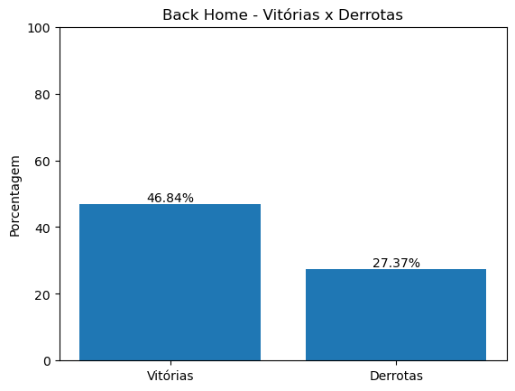

```python
# Calcular a taxa de acertos (vitórias / total de jogos) e de erros (derrotas / total de jogos), multiplicadas por 100
porcentagem_acertos = round(len(win) / len(base) * 100, 2)
porcentagem_erros = round(len(lose) / len(base) * 100, 2)

# Plotar um gráfico de barras com as taxas de acertos e erros
fig, ax = plt.subplots()
bars = ax.bar(['Vitórias', 'Derrotas'], [porcentagem_acertos, porcentagem_erros])
ax.set_ylabel('Porcentagem')
ax.set_title('Back Home - Vitórias x Derrotas')

# Adicionar labels com as porcentagens nas barras
for bar in bars:
    yval = bar.get_height()
    ax.text(bar.get_x() + bar.get_width()/2, yval, f'{yval}%', va='bottom', ha='center')

plt.ylim(0, 100)  # Definir os limites do eixo y para a porcentagem
plt.show()
```

Podemos visualizar a vantagem que tem um time jogando em casa, essa é uma peculiaridade de basicamente todas as ligas, embora o Back Home não seja um método seguro, pois se contabilizarmos os empates e as derrotas teríamos 53,16% do mandante não ganhar.

Por hoje é só, até a próxima postagem!